Systematic Review

Biological Augmentation and Tissue Engineering

Approaches in Meniscus Surgery

Cathal J. Moran, M.D., F.R.C.S.(Orth), Alberto Busilacchi, M.D., Cassandra A. Lee, M.D.,

Kyriacos A. Athanasiou, Ph.D., and Peter C. Verdonk, M.D., Ph.D.

Purpose: The purpose of this review was to evaluate the role of biological augmentation and tissue engineering strategies

in meniscus surgery. Although clinical (human), preclinical (animal), and in vitro tissue engineering studies are included

here, we have placed additional focus on addressing preclinical and clinical studies reported during the 5-year period used

in this review in a systematic fashion while also providing a summary review of some important in vitro tissue engineering

ﬁndings in the ﬁeld over the past decade. Methods: A search was performed on PubMed for original works published

from 2009 to March 31, 2014 using the term “meniscus” with all the following terms: “scaffolds,” “constructs,” “cells,”

“growth factors,” “implant,” “tissue engineering,” and “regenerative medicine.” Inclusion criteria were the following:

English-language articles and original clinical, preclinical (in vivo), and in vitro studies of tissue engineering and regen-

erative medicine application in knee meniscus lesions published from 2009 to March 31, 2014. Results: Three clinical

studies and 18 preclinical studies were identiﬁed along with 68 tissue engineering in vitro studies. These reports show the

increasing promise of biological augmentation and tissue engineering strategies in meniscus surgery. The role of stem cell

and growth factor therapy appears to be particularly useful. A review of in vitro tissue engineering studies found a large

number of scaffold types to be of promise for meniscus replacement. Limitations include a relatively low number of clinical

or preclinical in vivo studies, in addition to the fact there is as yet no report in the literature of a tissue-engineered

meniscus construct used clinically. Neither does the literature provide clarity on the optimal meniscus scaffold type or

biological augmentation with which meniscus repair or replacement would be best addressed in the future. There is

increasing focus on the role of mechanobiology and biomechanical and biochemical cues in this process, however, and it is

hoped that this may lead to improvements in this strategy. Conclusions: There appears to be signiﬁcant potential for

biological augmentation and tissue engineering strategies in meniscus surgery to enhance options for repair and

replacement. However, there are still relatively few clinical studies being reported in this regard. There is a strong need for

improved translational activities and infrastructure to link the large amounts of in vitro and preclinical biological and tissue

engineering data to clinical application. Level of Evidence: Level IV, systematic review of Level I-IV studies.

See commentary on page 956

T

he meniscus plays a key role in joint congruency,

load distribution, enhanced stability, and assistance

in lubrication and nutrition at the level of the knee.<sup>1</sup>

Surgical

intervention

for

the

injured

symptomatic relief being the primary concern of the

patient. More than 1.5 million meniscus procedures are

performed across the United States and Europe annu-

ally, most often partial meniscectomy for an irreparable

lesion.<sup>2</sup>However, once the normal functions of the

meniscus are impaired, chondroprotection is disrupted,

and the risk of degenerative change and related

morbidity is increased.<sup>3</sup>It follows that restoring normal

meniscus

form

and

function

through

repair

or

replacement may be in the interest of the long-term

health of the knee.

Although it is now known that meniscus repair is the

preferred option for patients with a meniscus lesion,

there

are

many

situations

in

which

this

is

not

possiblede.g., lesions affecting the inner third of the

From Sports Surgery Clinic and Trinity College Dublin (C.J.M.), Dublin,

Ireland; Antwerp Knee Centre, AC Monica Hospitals (P.C.V.), Antwerp,

Belgium; Clinical Orthopaedics, Università Politecnica delle Marche (A.B.),

Ancona, Italy; Departments of Orthopaedic Surgery & Biomedical Engineer-

ing, University of California (C.A.L., K.A.A.), Davis, California, U.S.A.

The authors report the following potential conﬂict of interest or source of

funding: P.V. receives support from Orteq Sport Medicine.

Received July 18, 2014; accepted November 19, 2014.

Address correspondence to Cathal J. Moran, M.D., F.R.C.S.(Orth), Sports

Surgery Clinic, Santry Demesne, Santry, Dublin 9, Ireland. E-mail:

cathaljmoran@gmail.com

� 2015 by the Arthroscopy Association of North America

0749-8063/14626/$36.00

http://dx.doi.org/10.1016/j.arthro.2014.11.044

944

Arthroscopy: The Journal of Arthroscopic and Related Surgery, Vol 31, No 5 (May), 2015: pp 944-955

meniscus, an area known to have a limited vascular

supply and healing potential.<sup>4</sup>Degenerative tears of the

meniscus are also unlikely to heal if repaired because of

the pattern of the tear, the quality of the tissue, and the

typically older patient proﬁle with which they are most

often associated. The preceding tear types are therefore

usually an indication for meniscectomy. Furthermore,

even when tears seem to have the ideal physical and

biological characteristics for repair, we know that there

remains a failure rate of up to 30%.<sup>5</sup>Although there are

now increased data to support the use of synthetic and

allograft meniscus replacement material in advanced

cases of meniscus loss, even under appropriate in-

dications these options are impaired by a lack of uni-

versal efﬁcacy and limited availability.<sup>6,7</sup>For this reason,

the consideration of biological augmentation and tissue

engineering approaches to meniscus repair and replace-

ment is important for surgeons and scientists alike.

Biological augmentation strategies attempt to over-

come the inherent limitations in healing related to

poor vascularity and heterogeneous cellularity by

promoting

chemotaxis,

cellular

proliferation,

and

matrix production at the repair site. Mechanical

techniques traditionally used to stimulate healing by

creating vascular access and stimulating cells, cyto-

kines, and bone marrow cells in the vicinity of the

repair are representative of early augmentation stra-

tegies. These techniques have been applied clinically

over the years with varying clinical outcomes.<sup>5,8</sup>The

provision of exogenous ﬁbrin clot, growth factors, and

cells from various sources to the meniscus repair site

have also been previously noted in the literature.<sup>9-12</sup>

Although the term “tissue engineering” has been

applied to a multitude of biological strategies in pre-

vious literature, it correctly refers to the addition of

cells or growth factors to a scaffold with the aim of

host target tissue regeneration. This strategy may

involve varying levels of focus on both ex vivo and

in vivo meniscus tissue generation before and after

implantation

into

the

host.

However,

of

critical

importance is the understanding that current models

of meniscus tissue engineering must also provide for

the impact of mechanobiology (the effects of implant

and tissue loading in the knee on cellular function and

tissue formation).<sup>13</sup>This concept has grown in focus in

recent years in the overall world of tissue engineering

and regenerative medicine; it is of particular impor-

tance when considering musculoskeletal tissues. It

may be of particular beneﬁt to consider this in areas in

which we have struggled in our efforts to make

further

advances

toward

the

satisfactory

literature as it relates to original reports of biological

augmentation and tissue engineering approaches in

meniscus surgery. Because it is impossible to provide a

comprehensive systematic overview of the entire litera-

ture in this ﬁeld, which would cover all published reports

of clinical (human), preclinical (animal), and in vitro

studies, we have focused this review on studies reported

in the past 5 years. The preceding period has also pre-

viously been addressed in this journal.<sup>14</sup>We place

particular focus on addressing preclinical and clinical

studies reported during this 5-year period in a systematic

fashion while also providing a summary of some

important in vitro tissue engineering ﬁndings in the ﬁeld

over this period. This approach serves to highlight the

trends in the ﬁeld, reveal the limited progress from

in vitro investigations to clinical trials, and promote an

understanding of the need for greater translational

interaction to drive the process forward from here. The

role of synthetic scaffolds used in isolation is not

addressed in this article because it is dealt with in a

separate focused review in this issue of Arthroscopy.

Methods

A search was performed on PubMed for original

works published from 2009 to March 31, 2014 using

the term “meniscus” with all the following terms:

“scaffolds,”

“constructs,”

“cells,”

“growth

factors,”

“implant,”

“tissue

engineering,”

and

“regenerative

medicine” (Table 1). Inclusion criteria for the clinical

and preclinical sections were the following: English-

language articles and original clinical and preclinical

(in vivo) studies of Tissue Engineering and Regenera-

tive Medicine (TERM) application in knee meniscus

lesions published from 2009 to March 31, 2014. To

provide

an

up-to-date

summary

of

some

of

the

to March 31, 2014 were also considered for the in vitro

tissue engineering section, and some of the most

important articles were chosen. All abstracts were

evaluated. Only Level I to IV clinical studies were

considered for the clinical section. When an article was

included, the full-text article was reviewed, and refer-

ence lists and related electronic libraries were checked.

All articles identiﬁed by these search terms were

manually reviewed and discussed among us, and a

decision was made regarding inclusion or exclusion.

Results

Clinical Studies 2009 to 2014

We identiﬁed 3 clinical articles relating to biological

augmentation and tissue engineering approaches to

meniscus repair or regeneration in the past 5 years

(Table 2). Jang et al.<sup>15</sup>described a standardized

arthroscopic technique to deliver additional autolo-

gous ﬁbrin clot to inside-out sutures. This was reported

to have a success rate of 95% (39 of 41 patients). This

series included 41 meniscus tears (19 radial tears, 12

longitudinal tears in the red-white zone, 7 transverse

MENISCUS ENGINEERING

945

tears, and 3 oblique tears). Ra et al. also investigated

the efﬁcacy of inside-out meniscus sutures in associa-

tion with ﬁbrin clot placed inside radial meniscus tears.

At a mean of 30 � 4 months postoperatively, the

Lysholm score was noted to have improved from

65 � 6 to 94 � 3 and the International Knee Docu-

mentation Committee subjective knee score improved

from 57 � 7 to 92 � 3. Second-look arthroscopy

showed complete healing of the meniscus lesion in 6 of

7 cases. These data support previous studies that

showed a beneﬁt to using ﬁbrin clot in meniscus sur-

gery.<sup>9,16,17</sup>The delivery mechanism described by Jang

et al. may provide a user-friendly technique for

applying this strategy more frequently in the clinical

setting.

In 2014, Vangsness et al.<sup>18</sup>reported on a randomized

double-blind controlled study investigating the safety of

intra-articular injection of human mesenchymal stem

cells (MSCs) into the knee, the ability of MSCs to pro-

mote meniscus regeneration after partial meniscec-

tomy, and the effects of MSCs on osteoarthritic changes

in the knee. A total of 55 patients at 7 institutions un-

derwent

partial

medial

meniscectomy.

A

single

superolateral knee injection was given within 7 to

10 days after meniscectomy. Patients were randomized

to 1 of 3 treatment groups: group A, in which patients

received an injection of 50 � 10<sup>6</sup>allogeneic MSCs;

group B, in which patients received 150 � 10<sup>6</sup>alloge-

neic MSCs; and the control group, which received a

sodium

hyaluronate

(hyaluronic

acid/hyaluronan)

vehicle control. Patients were followed to evaluate

safety, meniscus regeneration, overall condition of the

knee joint, and clinical outcomes at intervals over

2 years. Evaluations included sequential magnetic

resonance imaging (MRI). No ectopic tissue formation

or clinically important safety issues were identiﬁed.

There was signiﬁcantly increased meniscus volume

(deﬁned a priori as a 15% threshold) determined by

quantitative MRI in 24% of patients in group A and in

6% of patients in group B at 12 months after menis-

cectomy (P ¼ .022). No patients in the control group

met the 15% threshold for increased meniscus volume.

Based on visual analog scale assessments, patients with

osteoarthritic changes who received MSCs experienced

a signiﬁcant reduction in pain compared with those

who received the control vehicle.

Preclinical In Vivo Studies 2009 to 2014

We identiﬁed 18 preclinical in vivo studies relating to

the biological augmentation and tissue engineering

approaches to meniscus repair or regeneration pub-

lished in the past 5 years (Table 3). These reports

included both large animal models, such as goats,

sheep, and swine, as well as smaller animal models,

including rats, rabbits, and mice. The heterogeneity of

experimental models testing the different treatments is

also evident in Table 3. However, these reports do

appear to provide promising data as to the potential

beneﬁt of biological treatments.

Regarding

the

potential

beneﬁts

of

augmenting

meniscus repair with stem cells alone, in a “sandwich”

model in nude mice Scotti et al.<sup>27</sup>showed that

meniscus layers containing ﬁbrochondrocytes in ﬁbrin

glue improved bonding and integration compared with

acellular ﬁbrin. Furthermore, the ﬁbrin gel appeared to

be a valid vehicle for cell migration and viability to

promote ﬁbrocartilaginous differentiation. In a rat

model of meniscus defects, Horie et al.<sup>28</sup>not only re-

ported the regenerative effects of synovial stem cells

injected into the joint but also their differentiation to a

meniscus lineage. This was shown through histologic

data, immunostaining, and molecular analysis based on

model, Horie et al.<sup>29</sup>injected synovial MSCs to stimu-

late the healing of a 1.5-mmediameter defect in

meniscus and noted a signiﬁcantly improved regener-

ative response compared with their control of phos-

phate buffered saline alone. Ferris et al.<sup>30</sup>reported on a

construct of meniscus layers and ﬁbrin glue loaded with

equine bone marrow stromal cells (BMSCs). They

showed increased vascularization, thinner repair tissue,

and better bonding with surrounding tissue when the

construct with MSCs was compared with constructs

without cells. Desando et al.<sup>31</sup>investigated the potential

of adipose tissueederived stem cells for meniscus

repair, showing that these cells were able to improve

healing of cartilage and meniscus defects in a rabbit

osteoarthritis model. Finally, although all the studies

mentioned point to the potential beneﬁts of stem cell

augmentation, in a meniscus pullout suture enhanced

with human BMSCs versus simple sutures alone in a

rabbit model, Hong et al.<sup>32</sup>did not show signiﬁcantly

The role of growth factors has also been addressed in

animal preclinical studies, both with and without

cellular therapy or scaffold use. Zhang et al.<sup>33</sup>found

that full-thickness meniscus tears in the avascular zone

in a goat model showed enhanced repair when treated

with human insulin-like growth factor 1 (hIGF-1)e

meshed BMSCs in an injectable solution. Their study

histologically

and

biochemically

showed

that

the

meniscus defect was completely ﬁlled at 16 weeks after

Table 1. Summary of the Data and Main Variables That Were

Assessed During This Systematic Review

Search Terms:

Meniscus + one of the following terms:

Scaffolds, constructs, cells, growth factors, implant, tissue

engineering, regenerative medicine

Criteria: English language original study

Type: Clinical or preclinical (Evidence Level I-IV for clinical articles)

Dates: 2009-March 31, 2014

946

C. J. MORAN ET AL.

treatment. He et al.<sup>34</sup>performed a study in rabbits using

growth factors in ﬁbrin glue. Their study found that

connective tissue growth factor enhanced healing in

defects of the avascular zone of the meniscus by stim-

ulating the neosynthesis of both collagen types 1 and 2.

Ionescu et al.<sup>35</sup>published a bovine study that evaluated

the in vivo effect of basic ﬁbroblast growth factor

(bFGF) as a promitotic agent and transforming growth

factor-b3 (TGF-b3) as a pro-matrix forming agent on

meniscus

repair

and

integration

with

synthetic

meniscus scaffolding. In the short term, delivery of

bFGF or sustained delivery of TGF-b3 increased both

juvenile and adult tissue formation. In addition TGF-b3

stimulated an increase in proteoglycans in the longer

term. Zellner et al.<sup>36</sup>carried out a study comparing

different strategies to ﬁx meniscus defects in the white

zone in a rabbit model, comparing suture, ﬁbrin matrix

seeded and not seeded with BMSCs, platelet-rich

plasma, and an untreated defect. They reported a sig-

niﬁcant healing rate when MSCs were used. Moriguchi

et al.<sup>37</sup>developed an experimental tissue-engineered

construct of synovial MSCs and ascorbic acid, showing

signiﬁcantly improved healing of 4-mm defects in the

avascular zone of the meniscus after 6 months. Finally,

Esparza et al.<sup>38</sup>assessed in vivo collagen gene expres-

sion by synovial meniscus cells after stimulation to

vascular endothelial growth factor (VEGF), TGF-b,

bFGF, and IGF. Data were reported for different areas of

meniscus in vivo and showed that growth factors may

exert different effects in different regions of the

meniscus.

Biological Augmentation and Tissue Engineering

Approaches In Vitro

Although there has been limited progression of scaf-

folds combined with cells or growth factors into pre-

clinical studies, the in vitro tissue engineering literature

is too vast to review all individual studies in a systematic

manner here. However, some important ﬁndings and

trends were noted. It has now been shown that various

scaffolds (e.g., synthetic, extracellular matrix [ECM]

constituent, tissue derived, and hydrogels) for meniscus

tissue regeneration each have their own inherent ad-

vantages. Regarding their incorporation into meniscus

substitutes, ﬁnite element models have shown that

circumferential and axial/radial moduli are important

determinants of the contact pressure distribution by the

native meniscus and thus should ideally be matched in

any replacement technology.<sup>39</sup>A signiﬁcant advantage

of synthetic scaffolds is the relative ease of manipula-

tion of their biomechanical properties, whereas natural

scaffolds may possess inherent advantages for cellular

interaction. It has now also been shown that electro-

spun

synthetic

scaffolds

(e.g.,

poly-E-caprolactone

[PCL]) may provide an appropriate microarchitectural

environment for meniscus cells. The nanoﬁbers created

Table 2. Clinical Studies of Meniscal Repair With Biological Augmentation 2009-2014

Reference

Defect

Strategy

Cells

Control

Outcome Measure

Jang et al.15

(2011)

41 meniscus tears

(19 radial, 12 longitudinal

in the red-white zone, 7

transverse, 3 oblique tears)

Inside-out sutures and

ﬁbrin clot

NA

NA

MRI and arthroscopic second look

Average follow-up 8.3 mo

Ra et al.19 (2013)

12 meniscal tears: 9 in

the lateral meniscus and

3 in the medial meniscus

Inside-out sutures and

ﬁbrin clot

NA

NA

Lysholm and IKDC subjective scores

at 2-yr follow-up: both signiﬁcantly

improved from 65 � 6 and 57 � 7 to

94 � 3 and 92 � 3, respectively

Vangsness

et al.18 (2014)

55 medial subtotal

meniscectomies (> 50%)

Administration of A-MSCs

injected in the knee 1 wk

postoperatively

Group A: dose of 50 � 106

A-MSCs; Group B, 150 � 106

A-MSCs

Administration of one

injection of hyaluronic acid

2-yr follow-up: MRI showed signiﬁcant

meniscus regeneration (15% threshold)

in 24% of patients in group A and 6%

in group B at 12 mo after meniscectomy

No improvement in control group

A-MSCs, allogeneic mesenchymal stem cells; GF, growth factor; IKDC, International Knee Documentation Committee; MRI, magnetic resonance imaging; NA, not applicable.

MENISCUS ENGINEERING

947

may provide an increased biomechanical advantage of

the temporizing structure and of the regenerated

meniscus by helping to organize and optimize the

3-dimensional (3D) orientation of ECM deposition in

the circumferential direction while facilitating cellular

inﬁltration through the scaffold’s ﬁbers.<sup>40-42</sup>At the

same time, 3D woven PCL scaffolds have conferred

increased biomechanical properties in a composite

preparation with cartilage-derived matrix, obviating the

need

for

growth

factor

augmentation,

and

may

certainly be applied to meniscus restoration.<sup>43,44</sup>Gunja

et al.<sup>45-48</sup>have conducted work using nonwoven poly-

L-lactic acid scaffolds exploring the positive synergistic

effects of bFGF and hypoxia, hydrostatic pressure, and

TGF-ß and coculture (chondrocytes and meniscus cells)

using in vitro models.

Ultimately, it is hoped that cellular inﬁltration and

matrix deposition may restore some of the viscoelastic

properties of meniscus tissue in which the ﬂuid phase

carries

a

signiﬁcant

amount

of

the

load.<sup>49</sup>

The

biocompatibility and biomimetic properties of ECM

constituent scaffolds have therefore led to their use in

this situation despite their inferior biomechanical pro-

ﬁles. Balint et al.<sup>50</sup>reported the use of a collagen

scaffold reinforced by a network of degradable tyrosine-

derived polymer ﬁbers that showed circumferential

tensile strength stiffness and hoop stress behavior under

compressive loading that mimics the normal meniscus.

Hydrogels (natural or synthetic) are biochemically

versatile and can be used as cell and growth factor

delivery

systems.<sup>13</sup>

Although

their

biomechanical

properties can be tailored somewhat by substrate con-

centration and composition, they often fall short of

native meniscus properties. To overcome this problem,

Holloway et al.<sup>51</sup>proposed a ﬁber-reinforced composite

containing ultra-high-molecular-weight polyethylene

ﬁbers in a polyvinyl alcohol hydrogel and varied the

composition and orientation of the ﬁbers to mimic

native meniscus properties for total meniscus replace-

ment. On implantation in a dynamic cadaveric model,

this construct was seen to restore contact mechanics to

a level comparable to that of meniscus allograft trans-

plantation.<sup>52</sup>Anatomically shaped alginate hydrogels

have been fabricated using extracted geometries from

MRI

and

microcomputed

tomography

and

show

improved biochemical and mechanical properties after

seeding with ﬁbrochondrocytes and supplementation

with IGF-1.<sup>53</sup>Tissue-derived scaffolds under current

investigation

include

small

intestine

submucosa

(porcine) and silk scaffolds. The use of xenogeneic

meniscus tissue is currently being investigated in ani-

mal models and may provide a solution for partial

meniscus replacement. Indeed, processing of ovine

meniscus

tissue

to

improve

porosity

and

inter-

connectivity as a xenogeneic meniscus scaffold has

potential.<sup>54</sup>

There are growing data to show that the use of dy-

namic culture or ﬂuid mixing can be optimized to

modulate

the

spatial

heterogeneity

of

engineered

menisci as well as the correlated mechanical proper-

ties.<sup>55-57</sup>Compressive deformation or hydrostatic pres-

sure has been shown to enhance the structure and

function of engineered meniscus tissues.<sup>58-60</sup>Dynamic

compression of constructs based on microchanneled

scaffolds resulted in aligned cell layers and collagen

ﬁbers,<sup>58</sup>whereas hydrostatic pressure combined with

TGF-b1

increased

collagen

and

glycosaminoglycan

deposition by meniscus cells, ultimately leading to

enhanced

compressive

properties.<sup>45</sup>

Cyclic

tension

speciﬁcally stimulated collagen type I mRNA expression

and protein synthesis but had no effect on collagen type

II, aggrecan, or osteocalcin mRNA levels, resulting in

enhanced ﬁbrochondrocyte-like differentiation of bone

marrowederived MSCs.<sup>59</sup>Combinatorial modes of

mechanical stimulation, including tension-compression

loading<sup>60</sup>or perfusion and cyclic compression,<sup>61</sup>were

also reported to additively increase matrix production

and tissue mechanical properties.

Another area of focus in tissue engineering of carti-

lage and the meniscus is the concept of scaffold-free

self-assembly (Fig 1).<sup>62</sup>With this strategy, cells are

seeded densely in nonadherent molds and manipulated

to enhance cell-cell interactions, which initiates a pro-

cess akin to a developmental one, allowing the forma-

tion of a matrix with adequate mechanical properties.<sup>63</sup>

Cells naturally form a bioactive microenvironment that

may increase the likelihood of integration with host

tissue because of its biocompatibility. Growth factors

such

as

bFGF,

platelet-derived

growth

factor-AB,

endothelial

growth

factor,

and

TGF-b

have

been

shown to promote matrix synthesis as well as cellular

proliferation

and

migration.<sup>64-67</sup>

With

exogenous

agents such as chondroitinase ABC, self-assembled

meniscus constructs have been shown to increase

collagen content 196% per wet weight, 136% in

compressive instantaneous modulus, 68% in compres-

sive relaxation modulus, 600% in circumferential

tensile modulus, and 500% in radial tensile modulus.<sup>60</sup>

By increasing the circumferential and radial tensile

modulus, anisotropy can be achieved. In addition,

mechanical stimulation (hydrostatic pressure) has also

been shown to improve mechanical properties.<sup>68,69</sup>

Because

the

meniscus

undergoes

direct

loading

in vivo, these self-assembled constructs may provide a

more physiological and biological implant in meniscus

replacement.

Discussion

Meniscus repair and replacement is an area of

growing investigation. Recent data from clinical, pre-

clinical, and in vitro investigations have provided much

support for the ongoing research in this ﬁeld. However,

948

C. J. MORAN ET AL.

Table 3. Preclinical Studies of Biological Augmentation and Tissue Engineering in Meniscus Surgery 2009-2014

Reference

Animal

Defect/Model

Strategy

Cells

GF

Other

Control

Outcome Measure

Zhang

et al.33

(2009)

Goats

Full-thickness

experimental

defect anterior

horn tear in

white area

Injection of cell- loaded

gel into the defect

Bone marrow

mesenchymal stem

cells transfected

with HIGF1 gene

NA

NA

3 control groups:

cells without

transfection, gel

without cells,

and defect left

untreated

Histology, electron

microscopy proteoglycan

determination, MRI.

Scotti et al.27

(2009)

Swine

Meniscal construct

implanted in nude

mice

Construct with cells

in ﬁbrin glue

Swine chondrocytes

seeded on ﬁbrin glue

NA

NA

Construct with

acellular ﬁbrin glue

Histology and

Electron Microscopy

Horie et al.28

(2009)

Lewis rat

transgenic

(Luc/LacZ)

Massive meniscal

defect

Intra-articular cell

injection

Rat synovium MSCs

NA

NA

NA

Electron microscopy,

Histology, Real

Time PCR

Zellner et al.36

(2010)

New Zealand

white rabbit

2-mm defect

anterior lateral

meniscus

Hyaluronan-collagen

matrix with bone

marrow or MSC

Autologous MSC

(bone marrow)

NA

NA

Contralateral knee,

scaffold alone

Gross, histology

(integration,

immunohistochemistry)

Hong et al.32

(2011)

New Zealand

white rabbits

Anterior horn

defect

Transosseous pullout

suture þ cells

Human bone marrow

mesenchymal stem

cells

NA

Submeniscal

cartilage

defect

Simple pullout suture

Gross examination

and histology

Riera et al.20

(2011)

Swine

NA

Cell isolation and

cultivation

Meniscal cells

IL-1 alpha,

TNF-alpha,

TGF-b1

NA

Cells in 10%

serum without GF

stimulation

Micro wound assay.

Horie et al.29

(2012)

New Zealand

white rabbit

Cylindrical

meniscus defect

Intra-articular

cell injection

Allogenic synovium

MSCs in right knees

NA

NA

PBS þ saline alone

in left knees

Histology, ﬂuorescence

microscopy

Immunohistochemistry

Ionescu

et al.35

(2012)

Bovine

(juvenile

and adult)

Cylindrical

meniscus defect

Meniscus-to-meniscus

construct þ GFs

NA

Delivery

of bFGF,

TGF-b3 for

4 or 8 wk

Meniscus-to-

scaffold

construct þ

GFs

NA

Histology,

Biochemical contents,

Biomechanical tests.

Esparza et al.38

(2012)

Merino sheep

Synovial

vascularized

area of meniscus

Cell incubation of GFs

NA

VEGF

IGF

TGF

NA

Avascular area

of the meniscus

Col1, Col 2A, MMP-2

e MMP-13

expression

He et al.26

(2012)

New Zealand

white rabbits

3-mm defect in

meniscus

Delivery of GF

incorporated in

ﬁbrin glue

Fibrochondrocytes

Connective

tissue

growth

factor

NA

NA

Immunoﬂuorescence

Col1, Col2, VEGF

expression

Ferris et al.30

(2012)

Horses

Placement of

meniscal

construct in

nude mice

Construct þ ﬁbrin

glue þ cells

Bone marrow

mesenchymal stem

cells

NA

NA

Construct þ

ﬁbrin without cells

Gross evaluation,

H&E stain,

SOFG stain

Kon et al.21

(2012)

Bergamasca-

Massese

sheep

Subtotal medial

meniscectomy

Cell-scaffold (hyaluronic

acid HYAFF

polycaprolactone)

Autologous articular

chondrocytes

Acellular scaffold

and empty defect/

meniscectomy

Gross, histology,

OARSI cartilage

OA grading system

Gu et al.22

(2012)

Beagle dogs

Anterior horn

medial meniscus

PLGA scaffold with

autologous cells

Myoblasts cultured in

chondrogenic media

NA

Acellular PLGA

scaffold and

empty defect

Gross, histology

quality,

immunohistochemistry

(continued)

MENISCUS ENGINEERING

949

the reduction in the number of reports available in the

literature as one moves from a search of in vitro to

clinical studies reﬂects the immense difﬁculties that exist

in the translational arena from laboratory investigation

to clinical application. Safely taking advantage of the

potential of such new treatment options that may be on

the horizon is closely linked to the concept of trans-

lational research, the mechanisms by which we link

science and surgery, the laboratory, and the patient.<sup>70</sup>As

surgeons, our goal is ultimately to restore our patients to

a state of natural form and function through our surgical

interventions. In translational research, the relevant

questions are raised at the bedside by clinicians and

investigated in the laboratory and clinical research units

before bringing a suitable form of intervention back to

the bedside. It is critical that this process be applied in the

context of meniscus surgery if we are to make progress

in the ﬁeld. This challenge is highlighted by the fact that

the National Institutes of Health funded nearly $15

billion of basic science research in 2009.<sup>71</sup>Unfortunately,

current statistics indicate that less than 25% of highly

promising biomedical discoveries result in a published

randomized clinical trial, and less than 10% are estab-

lished in clinical practice within 20 years.<sup>71</sup>The trend in

the data available for the techniques considered in this

article suggests that approaches in biological augmenta-

tion and tissue engineering for meniscus repair are also

being affected in this manner.

Although we have highlighted a large number of

preclinical studies in this review, it is readily apparent

that there is signiﬁcant heterogeneity present in the

studies reported. The need to identify appropriate

translational models in regenerative repair is therefore

of critical importance and worthy of particular consid-

eration here. Arnoczky et al.,<sup>72</sup>Chu et al.,<sup>73</sup>and Sah

and Ratcliffe<sup>74</sup>have previously addressed this issue

separately regarding articular cartilage, the meniscus,

and regenerative medicine in general, and readers are

referred to these texts for comprehensive coverage of

this important issue. Ultimately, there are many animal

models that are used in meniscus and articular cartilage

defect research. One can appreciate that various models

offer distinct advantages and disadvantages for studying

regenerative repair strategies. It is readily apparent that

no one animal model reproduces all the features of the

human injury condition regardless of the clinical con-

dition being evaluated. All animals differ from humans

regarding the biomechanical use of their joints. Large

animal models such as the goat or the horse may more

closely resemble the human than smaller animal

models such as rodents or rabbits. However, it is usually

not ﬁscally feasible or practical to conduct initial

experiments in larger species. Also, because no animal

is immunologically identical to the human, a possible

adverse immunologic response to a regenerative med-

icine therapy in human patients may not be predicted

Table 3. Continued

Reference

Animal

Defect/Model

Strategy

Cells

GF

Other

Control

Outcome Measure

Desando

et al.31

(2013)

New Zealand

white rabbit

OA induced after

ACL transection

Intra-articular

cell injection

ASCs

NA

Role in Meniscal

healing

and anti-

inﬂammatory

role of cell

administration

NA

Laverty’s Score,

Col1, Col2, MMP-1,

MMP-3, TNF-alpha

expression in cartilage,

synovium and menisci.

Zellner

et al.36

(2013)

New Zealand

white rabbit

4-mm meniscus

defect

HA-Col matrix þ

PRP or cells

Bone marrow

mesenchymal stem

cells

PRP

NA

Suture with No. 5-0

thread

Gross examination,

Histology,

Biomechanical tests

Moriguchi

et al.23

(2013)

Swine

4-mm cylindrical

defect

Construct of cells

and ascorbic acid

Allogenic synovium

MSCs

NA

NA

2 control groups:

defect untreated

and normal meniscus

Histology,

Histomorphometry

Esposito

et al.24

(2013)

New Zealand

white rabbit

Medial meniscus

resection

PLDLA/PCL-T scaffold

with allogeneic cells

Allogeneic

ﬁbrochondrocytes

NA

NA

Cell-free scaffolds

v no implant

Gross, histology,

histomorphometry

Hatsushika

et al.25

(2013)

Japanese white

rabbits

Anterior horn

Medial

meniscus excision

Cell injection

Allogeneic Synovial

MSCs

NA

NA

PBS

Histologic quantiﬁcation,

OARSI cartilage OA

grading

ACL, anterior cruciate ligament; ASCs, adipose stem cells; bFGF, basic ﬁbroblast growth factor; GF, growth factor; H&E, haematoxylin and eosin; HA-Col, hyaluronic acid-collagen; HYAFF,

hyaluronic acid scaffold; IGF, insulin-like growth factor; MMP, matrix metalloproteinase; MRI, magnetic resonance imaging; MSC, mesenchymal stem cell; OA, osteoarthritis; OARSI, Osteo-

arthritis Research Society International; NA, not applicable; PBS, phosphate-buffered saline; PCL-T, polycaprolactonetriol; PCR, polymerase chain reaction; PLDLA, poly-L/D-lactide; PLGA, poly

(lactic-co-glycolic acid); PRP, platelet-rich plasma; SOFG, Safranin O-Fast Green; TGF, transforming growth factor; TNF, tumor necrosis factor; VEGF, vascular endothelial growth factor.

950

C. J. MORAN ET AL.

from animal studies. Although a nonhuman primate

shoulder, e.g., may offer more anatomic, biomechan-

ical, and immunologic similarities to humans than do

other animals, cost and management issues make use of

this model impractical. Therefore, it is generally well

accepted that a small animal model will be chosen for

initial lines of investigation. However, ﬁnal preclinical

evaluation of a clinical strategy for a repair or recon-

struction technique may require conﬁrmation in a large

animal model before trials in humans. Although sci-

entists may play the leading role in selecting animal

models for preclinical testing, it does not make sense for

this process to be ignored by surgeons.

Ultimately, the design of a successful meniscus scaf-

fold, while providing a degree of biomechanical stability

in the short term, should incorporate features amenable

to cellular inﬁltration at the meniscus tissue interface.

These include consideration of pore size and inter-

connectivity while maintaining a near-native meniscus

compression modulus to exert a proﬁbrochondrogenic

effect.<sup>75</sup>Mesenchymal stem cells, ﬁbrochondrocytes,

and chondrocytes have now all been successfully

incorporated into cell-scaffold complexes and show

promising results in both in vitro and in vivo studies.

The overwhelming issue with the latter 2 cell types is

availability. The use of autologous ﬁbrochondrocytes/

chondrocytes requires a 2-step operative process. Given

the relative scarcity of these cells in the tissue, mono-

layer expansion is also required, which can result in

downregulation of genes involved in matrix produc-

tion.<sup>76</sup>Allogenic and xenogeneic cell sources have

shown promise in animal models, and although they

may overcome the discrepancy in supply and demand,

they are fraught with translational issues.<sup>77,78</sup>MSCs, in

contrast, have been successfully isolated from adipose

tissue, muscle, and bone marrow and subsequently

used in soft tissue engineering.<sup>79</sup>It is important to be

aware that bone marrow aspirate, concentrated (bone

marrow aspirate concentrate [BMAC]) or otherwise,

does not equate to using a puriﬁed or cultured collec-

tion of MSCs. Although MSCs are present within the

aspirate and concentrate, they are present in very low

numbers and are only one of a number of cell types

present. The possible advantage of BMAC, however, is

that it may be of beneﬁt for MSCs to remain among the

other biological factors present in BMAC. Although

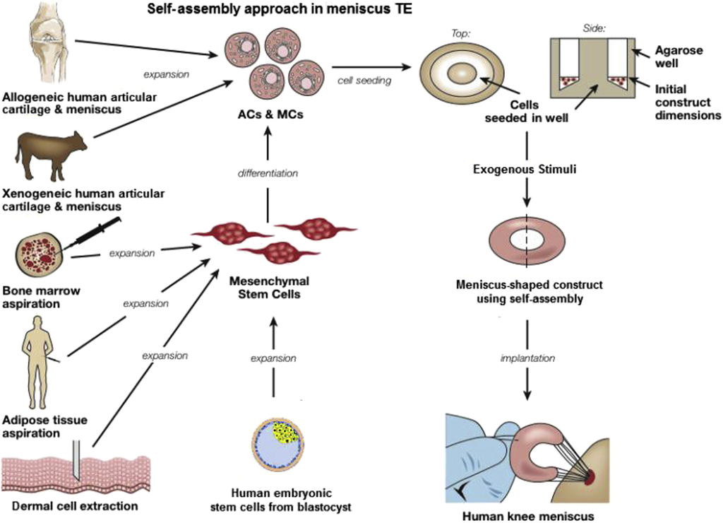

Fig 1. Strategy for self-assembly for meniscus tissue engineering. Reprinted with permission.<sup>13</sup>

MENISCUS ENGINEERING

951

further work on point-of-care strategies such as BMAC

is required, it may be that the next generation of

genetically manipulated MSCs may further enhance the

regenerative process by promoting growth factor pro-

duction and directed cell differentiation.<sup>80,81</sup>As another

cell type for discussion, synoviocytes have often been

overlooked

in

meniscus

regeneration

and

repair

augmentation.<sup>82</sup>This is despite the fact that meniscus

repair has been shown to be facilitated by ﬁbroblasts

from the surrounding synovium and joint capsule that

are believed to undergo ﬁbrocartilaginous metaplasia at

the repair site.<sup>83</sup>

Cell chemotaxis, maintenance of cellular phenotype,

and inducing matrix production are critical for the

biological integration of a meniscus scaffold. The roles

of biophysical and biochemical signaling are currently

under

review

in

this

regard.

Both

the

micro-

architectural environment and biomechanical proper-

ties of a scaffold material act as biophysical cues for

seeded and inﬁltrated cells.<sup>13</sup>In addition, the effect of

mechanical loading on cellularized constructs, meniscus

explants, and scaffoldless-assembly meniscus tissue is

being investigated in an attempt to understand and use

the resultant cellular responses; these may have a role

in the maintenance of cell phenotype, matrix produc-

tion, and overall improved vital role of cell phenotype

maintenance and differentiation. Fibroblastic growth

factor 2 has been shown to recover the monolayer

expansion of meniscus cells, whereas TGF-ß1 has

caused meniscus cells to take on a more chondrogenic

phenotype.<sup>13</sup>As discussed, growth factor supplemen-

tation has shown improved cellular migration, prolif-

eration,

and

matrix

production,

but

important

translational considerations include mode of delivery,

localization of effect, and timing of growth factor

release. The use of innovative imaging markers in

future studies may prove efﬁcacious in tracking cell

migration and matrix production.

Regardless of the strategy applied, a key deﬁnition to

be achieved in the ﬁeld is the target level of function-

ality, which is required to support a superior clinical

outcome.

The

unique

anisotropic

features

of

the

meniscus may be nearly impossible to replicate or

generate.

Although

ex

vivo

maturation

is

often

mentioned, an increased level of maturation of engi-

neered meniscus grafts would require not only more

complex culture modalities but also likely longer cul-

ture durations, which in view of clinical translation

would be reﬂected in higher manufacturing costs. The

role of in vivo mechanobiology and the rehabilitation

process is therefore likely to be of vital importance to

making progress. In the translational process, surgeons

must be aware of the need to identify a match between

the properties of a meniscus graft and a suitable

regimen of postoperative rehabilitation. This process

may be assisted by the use of bioreactors applying

regimens of forces and ﬂuid dynamics mimicking those

at the site of implantation. This offers the opportunity to

investigate which structural and functional properties

are sufﬁcient to tolerate certain loading regimens that

would be experienced by the graft on implantation or,

alternatively, to help deﬁne which loading regimens are

compatible for grafts of a deﬁned functionality.<sup>84</sup>

However, it is difﬁcult for scientists or engineers to

address this matter alone without clinical and rehabil-

itation input. If these areas of expertise can be matched

appropriately, the introduction of bioreactor systems in

the manufacture of cellular grafts can be exploited, not

only to reach higher levels of tissue organization and

mechanical functionality but also to reduce operator

handling, automate processes, and ultimately stan-

dardize the quality of the product.<sup>85</sup>

Limitations

Limitations in this study relate to the relatively low

number of articles evaluating the clinical and preclinical

(animal model) investigation of meniscus tissue engi-

neering. In addition, there is as of yet no report in the

literature of a tissue-engineered meniscus construct

used clinically. Neither does the literature provide

clarity on the optimal meniscus scaffold type or the

biological augmentation with which meniscus repair or

replacement would be best addressed in the future.

There needs to be an increased focus on this specialized

ﬁeld of orthopaedic surgery, with an improved level of

communication across the clinician-scientist interface

to ensure that we deliver improved treatment options

going forward.

Conclusions

There appears to be signiﬁcant potential for biological

augmentation and tissue engineering strategies in

meniscus surgery to enhance options in repair and

replacement. However, there are still relatively few

clinical studies being reported in this regard. There is a

strong need for improved translational activities and

infrastructure to link the large amounts of in vitro and

preclinical biological and tissue engineering data to

clinical application.

References

1. Verdonk PC, Forsyth RG, Wang J, et al. Characterisation

of human knee meniscus cell phenotype. Osteoarthritis

Cartilage 2005;13:548-560.

2. Hutchinson MR. Are we wasting money on rehabilitation

for patients receiving workers’ compensation? Commen-

tary on an article by John Di Paola, MD: “Disability,

impairment,

and

physical

therapy

utilization

after

arthroscopic partial meniscectomy in patients receiving

workers’ compensation.” J Bone Joint Surg Am 2012;

94:e38.

952

C. J. MORAN ET AL.

3. King PJ, Bryant T, Minas T. Autologous chondrocyte

implantation for chondral defects of the knee: indications

and technique. J Knee Surg 2002;15:177-184.

4. Arnoczky SP, Warren RF. Microvasculature of the human

meniscus. Am J Sports Med 1982;10:90-95.

5. Maak TG, Fabricant PD, Wickiewicz TL. Indications for

meniscus repair. Clin Sports Med 2012;31:1-14.

6. Papalia R, Franceschi F, Diaz Balzani L, D’Adamio S,

Maffulli N, Denaro V. Scaffolds for partial meniscal

replacement: an updated systematic review. Br Med Bull

2013;107:19-40.

7. McCormick F, Harris JD, Abrams GD, et al. Survival and

reoperation rates after meniscal allograft transplantation:

analysis of failures for 172 consecutive transplants at a

minimum 2-year follow-up. Am J Sports Med 2014;42:

892-897.

8. Noyes FR, Heckmann TP, Barber-Westin SD. Meniscus

repair and transplantation: a comprehensive update.

J Orthop Sports Phys Ther 2012;42:274-290.

9. Arnoczky SP, Warren RF, Spivak JM. Meniscal repair

using an exogenous ﬁbrin clot. An experimental study in

dogs. J Bone Joint Surg Am 1988;70:1209-1217.

10. Kopf S, Birkenfeld F, Becker R, et al. Local treatment of

meniscal lesions with vascular endothelial growth factor.

J Bone Joint Surg Am 2010;92:2682-2691.

11. Scotti

C,

Hirschmann

MT,

Antinolﬁ

P,

Martin

Peretti GM. Meniscus repair and regeneration: review on<sup>I,</sup>

current methods and research potential. Eur Cell Mater

2013;26:150-170.

12. Taylor SA, Rodeo SA. Augmentation techniques for iso-

lated meniscal tears. Curr Rev Musculoskelet Med 2013;6:

95-101.

13. Makris EA, Hadidi P, Athanasiou KA. The knee meniscus:

structure-function, pathophysiology, current repair tech-

niques,

and

prospects

for

regeneration.

Biomaterials

2011;32:7411-7431.

14. Pereira H, Frias AM, Oliveira JM, Espregueira-Mendes J,

Reis RL. Tissue engineering and regenerative medicine

strategies

in

meniscus

lesions.

Arthroscopy

2011;27:

1706-1719.

15. Jang SH, Ha JK, Lee DW, Kim JG. Fibrin clot delivery

system for meniscal repair. Knee Surg Relat Res 2011;23:

180-183.

16. Henning CE, Lynch MA, Yearout KM, Vequist SW,

Stallbaumer RJ, Decker KA. Arthroscopic meniscal repair

using an exogenous ﬁbrin clot. Clin Orthop Relat Res

1990;252:64-72.

17. van

Trommel

MF,

Simonian

PT,

Potter

HG,

Wickiewicz TL. Arthroscopic meniscal repair with ﬁbrin

clot of complete radial tears of the lateral meniscus in the

avascular zone. Arthroscopy 1998;14:360-365.

18. Vangsness CT Jr, Farr J II, Boyd J, Dellaero DT, Mills CR,

Leroux-Williams M. Adult human mesenchymal stem

cells delivered via intra-articular injection to the knee

following partial medial meniscectomy: a randomized,

double-blind, controlled study. J Bone Joint Surg Am

2014;96:90-98.

19. Ra HJ, Ha JK, Jang SH, Lee DW, Kim JG. Arthroscopic

inside-out repair of complete radial tears of the meniscus

with a ﬁbrin clot. Knee Surg Sports Traumatol Arthrosc

2013;21:2126-2130.

20. Riera KM, Rothfusz NE, Wilus R, Weinberg JB, Guilak F,

McNulty A. Interleukin-1, tumor necrosis factor-alpha,

and transforming growth factor-beta 1 and integrative

meniscal repair: Inﬂuences on meniscal cell proliferation

and migration. Arthritis Res Ther 2011;13:R187.

21. Kon E, Filardo G, Tschon M, et al. Tissue engineering for

total meniscal substitution: Animal study in sheep modele

results at 12 months. Tissue Eng 2012;18:1573-1582.

22. Gu Y, Zhu W, Hao Y, Lu L, Chen Y, Wang Y. Repair of

meniscal defect using an induced myoblast-loaded poly-

glycolic acid mesh in a canine model. Exp Ther Med

2012;3:293-298.

23. Moriguchi Y, Tateishi K, Ando W, et al. Repair of meniscal

lesions using a scaffold-free tissue-engineered construct

derived from allogenic synovial MSCs in a miniature

swine model. Biomaterials 2013;34:2185-2193.

24. Esposito AR, Moda M, Cattani SM, et al. PLDLA/PCL-T

scaffold for meniscus tissue engineering. Biores Open Access

2013;2:138-147.

25. Hatsushika D, Muneta T, Nakamura T, et al. Repetitive

allogeneic intraarticular injections of synovial mesen-

chymal stem cells promote meniscus regeneration in a

porcine massive meniscus defect model. Osteoarthritis

Cartilage 2014;22:941-950.

26. He W, Liu YJ, Wang ZG, Guo ZK, Wang MX, Wang N.

Enhancement of meniscal repair in the avascular zone

using connective tissue growth factor in a rabbit model.

Chin Med J (Engl) 2011;124:3968-3975.

27. Scotti C, Pozzi A, Mangiavini L, et al. Healing of meniscal

tissue by cellular ﬁbrin glue: an in vivo study. Knee Surg

Sports Traumatol Arthrosc 2009;17:645-651.

28. Horie M, Sekiya I, Muneta T, et al. Intra-articular injected

synovial stem cells differentiate into meniscal cells directly

and promote meniscal regeneration without mobilization

to distant organs in rat massive meniscal defect. Stem Cells

2009;27:878-887.

29. Horie M, Driscoll MD, Sampson HW, et al. Implantation of

allogenic synovial stem cells promotes meniscal regener-

ation in a rabbit meniscal defect model. J Bone Joint Surg

Am 2012;94:701-712.

30. Ferris D, Frisbie D, Kisiday J, McIlwraith CW. In vivo

healing of meniscal lacerations using bone marrow-

derived mesenchymal stem cells and ﬁbrin glue. Stem

Cells Int 2012;2012:691605.

31. Desando G, Cavallo C, Sartoni F, et al. Intra-articular

delivery of adipose derived stromal cells attenuates oste-

oarthritis progression in an experimental rabbit model.

Arthritis Res Ther 2013;15:R22.

32. Hong JH, Park JI, Kim KH, Kim YM, Joo YB, Jeon YS.

Repair of the complete radial tear of the anterior horn of

the medial meniscus in rabbits: a comparison between

simple pullout repair and pullout repair with human bone

marrow stem cell implantation. Knee Surg Relat Res

2011;23:164-170.

33. Zhang H, Leng P, Zhang J. Enhanced meniscal repair by

overexpression of hIGF-1 in a full-thickness model. Clin

Orthop Relat Res 2009;467:3165-3174.

34. He W, Liu YJ, Wang ZG, Guo ZK, Wang MX, Wang N.

Enhancement of meniscal repair in the avascular zone

using connective tissue growth factor in a rabbit model.

Chin Med J (Engl) 2011;124:3968-3975.

MENISCUS ENGINEERING

953

35. Ionescu LC, Lee GC, Huang KL, Mauck RL. Growth factor

supplementation

improves

native

and

engineered

meniscus repair in vitro. Acta Biomater 2012;8:3687-3694.

36. Zellner J, Hierl K, Mueller M, et al. Stem cell-based tissue-

engineering for treatment of meniscal tears in the avas-

cular zone. J Biomed Mater Res B Appl Biomater 2013;101:

1133-1142.

37. Moriguchi Y, Tateishi K, Ando W, et al. Repair of meniscal

lesions using a scaffold-free tissue-engineered construct

derived from allogenic synovial MSCs in a miniature

swine model. Biomaterials 2013;34:2185-2193.

38. Esparza R, Gortazar AR, Forriol F. Cell study of the three

areas of the meniscus: effect of growth factors in an experi-

mental model in sheep. J Orthop Res 2012;30:1647-1651.

39. Haut Donahue TL, Hull ML, Rashid MM, Jacobs CR. How

the stiffness of meniscal attachments and meniscal mate-

rial

properties

affect

tibio-femoral

contact

pressure

computed using a validated ﬁnite element model of the

human knee joint. J Biomech 2003;36:19-34.

40. Baker MI, Walsh SP, Schwartz Z, Boyan BD. A review of

polyvinyl alcohol and its uses in cartilage and orthopedic

applications. J Biomed Mater Res B Appl Biomater 2012;100:

1451-1457.

41. Driscoll

TP,

Nerurkar

NL,

Jacobs

NT,

Elliott

DM,

Mauck RL. Fiber angle and aspect ratio inﬂuence the

shear mechanics of oriented electrospun nanoﬁbrous

scaffolds. J Mech Behav Biomed Mater 2011;4:1627-1636.

42. Fisher

MB,

Henning

EA, Soegaard

N,

Esterhai JL,

Mauck RL. Organized nanoﬁbrous scaffolds that mimic

the macroscopic and microscopic architecture of the knee

meniscus. Acta Biomater 2013;9:4496-4504.

43. Moutos FT, Estes BT, Guilak F. Multifunctional hybrid

three-dimensionally woven scaffolds for cartilage tissue

engineering. Macromol Biosci 2010;10:1355-1364.

44. Moutos FT, Guilak F. Functional properties of cell-seeded

three-dimensionally

woven

poly(epsilon-caprolactone)

scaffolds for cartilage tissue engineering. Tissue Eng Part

A 2010;16:1291-1301.

45. Gunja NJ, Athanasiou KA. Effects of hydrostatic pressure

on leporine meniscus cell-seeded PLLA scaffolds. J Biomed

Mater Res A 2010;92:896-905.

46. Gunja NJ, Huey DJ, James RA, Athanasiou KA. Effects of

agarose mould compliance and surface roughness on self-

assembled meniscus-shaped constructs. J Tissue Eng Regen

Med 2009;3:521-530.

47. Gunja NJ, Uthamanthil RK, Athanasiou KA. Effects of

TGF-beta1 and hydrostatic pressure on meniscus cell-

seeded scaffolds. Biomaterials 2009;30:565-573.

48. Gunja NJ, Athanasiou KA. Effects of co-cultures of

meniscus cells and articular chondrocytes on PLLA scaf-

folds. Biotechnol Bioeng 2009;103:808-816.

49. Spilker RL, Donzelli PS, Mow VC. A transversely isotropic

biphasic ﬁnite element model of the meniscus. J Biomech

1992;25:1027-1045.

50. Balint E, Gatt CJ Jr, Dunn MG. Design and mechanical

evaluation of a novel ﬁber-reinforced scaffold for meniscus

replacement. J Biomed Mater Res A 2012;100:195-202.

51. Holloway JL, Lowman AM, Palmese GR. Mechanical

evaluation of poly(vinyl alcohol)-based ﬁbrous compos-

ites as biomaterials for meniscal tissue replacement. Acta

Biomater 2010;6:4716-4724.

52. Gulotta

LV,

Wiznia

D,

Cunningham

M,

Fortier

L,

Maher S, Rodeo SA. What’s new in orthopaedic research.

J Bone Joint Surg Am 2011;93:2136-2141.

53. Puetzer JL, Brown BN, Ballyns JJ, Bonassar LJ. The effect

of

IGF-I

on

anatomically

shaped

tissue-engineered

menisci. Tissue Eng Part A 2013;19:1443-1450.

54. Spencer SJ, Saithna A, Carmont MR, Dhillon MS,

Thompson P, Spalding T. Meniscal scaffolds: early expe-

rience and review of the literature. Knee 2012;19:760-765.

55. Wendt D, Riboldi SA, Ciofﬁ M, Martin I. Potential and

bottlenecks of bioreactors in 3D cell culture and tissue

manufacturing. Adv Mater 2009;21:3352-3367.

56. Marsano A, Vunjak-Novakovic G, Martin I. Towards tis-

sue engineering of meniscus substitutes: selection of cell

source and culture environment. Conf Proc IEEE Eng Med

Biol Soc 2006;1:3656-3658.

57. Ballyns JJ, Wright TM, Bonassar LJ. Effect of media

mixing on ECM assembly and mechanical properties of

anatomically-shaped tissue engineered meniscus. Bio-

materials 2010;31:6756-6763.

58. Martinez H, Brackmann C, Enejder A, Gatenholm P.

Mechanical stimulation of ﬁbroblasts in micro-channeled

bacterial cellulose scaffolds enhances production of ori-

ented collagen ﬁbers. J Biomed Mater Res A 2012;100:

948-957.

59. Connelly JT, Vanderploeg EJ, Mouw JK, Wilson CG,

Levenston ME. Tensile loading modulates bone marrow

stromal cell differentiation and the development of engi-

neered ﬁbrocartilage constructs. Tissue Eng Part A 2010;16:

1913-1923.

60. Huey DJ, Athanasiou KA. Tension-compression loading

with chemical stimulation results in additive increases to

functional properties of anatomic meniscal constructs.

PLoS One 2011;6:e27857.

61. Petri M, Ufer K, Toma I, et al. Effects of perfusion and cyclic

compression on in vitro tissue engineered meniscus im-

plants. Knee Surg Sports Traumatol Arthrosc 2012;20:223-231.

62. Huey DJ, Hu JC, Athanasiou KA. Unlike bone, cartilage

regeneration remains elusive. Science 2012;338:917-921.

63. Huey DJ, Athanasiou KA. Maturational growth of self-

assembled, functional menisci as a result of TGF-beta1

and

enzymatic

chondroitinase-ABC

stimulation.

Bio-

materials 2011;32:2052-2058.

64. Stewart

K,

Pabbruwe

M,

Dickinson

S,

Sims

T,

Hollander AP, Chaudhuri JB. The effect of growth factor

treatment on meniscal chondrocyte proliferation and

differentiation on polyglycolic acid scaffolds. Tissue Eng

2007;13:271-280.

65. Tumia NS, Johnstone AJ. Platelet derived growth factor-

AB enhances knee meniscal cell activity in vitro. Knee

2009:1673-1676.

66. Pangborn CA, Athanasiou KA. Effects of growth factors

on

meniscal

ﬁbrochondrocytes.

Tissue

Eng

2005;11:

1141-1148.

67. Pangborn CA, Athanasiou KA. Growth factors and ﬁbro-

chondrocytes

in

scaffolds.

J

Orthop

Res

2005;23:

1184-1190.

68. Elder

SH,

Shim

JW,

Borazjani

A,

Robertson

HM,

Smith KE, Warnock JN. Inﬂuence of hydrostatic and

distortional

stress

on

chondroinduction.

Biorheology

2008;45:479-486.

954

C. J. MORAN ET AL.

69. Elder BD, Athanasiou KA. Synergistic and additive effects

of hydrostatic pressure and growth factors on tissue for-

mation. PLoS One 2008;3:e2341.

70. Moran CJ, Barry FP, Maher SA, Shannon FJ, Rodeo SA.

Advancing regenerative surgery in orthopaedic sports

medicine: the critical role of the surgeon. Am J Sports Med

2012;40:934-944.

71. Drolet BC, Lorenzi NM. Translational research: under-

standing the continuum from bench to bedside. Transl Res

2011;157:1-5.

72. Arnoczky SP, Cook JL, Carter T, Turner AS. Translational

models for studying meniscal repair and replacement:

what they can and cannot tell us. Tissue Eng Part B Rev

2010;16:31-39.

73. Chu CR, Williams A, Tolliver D, Kwoh CK, Bruno S III,

Irrgang JJ. Clinical optical coherence tomography of early

articular cartilage degeneration in patients with degener-

ative meniscal tears. Arthritis Rheum 2010;62:1412-1420.

74. Sah RL, Ratcliffe A. Translational models for musculo-

skeletal tissue engineering and regenerative medicine.

Tissue Eng Part B Rev 2010;16:1-3.

75. Klompmaker J, Jansen HW, Veth RP, Nielsen HK, de

Groot JH, Pennings AJ. Porous implants for knee joint

meniscus reconstruction: a preliminary study on the role

of pore sizes in ingrowth and differentiation of ﬁbro-

cartilage. Clin Mater 1993;14:1-11.

76. Gunja NJ, Athanasiou KA. Passage and reversal effects on

gene expression of bovine meniscal ﬁbrochondrocytes.

Arthritis Res Ther 2007;9:R93.

77. Weinand C, Peretti GM, Adams SB Jr, Bonassar LJ,

Randolph MA, Gill TJ. An allogenic cell-based implant for

meniscal lesions. Am J Sports Med 2006;34:1779-1789.

78. Revell CM, Athanasiou KA. Success rates and immuno-

logic responses of autogenic, allogenic, and xenogenic

treatments to repair articular cartilage defects. Tissue Eng

Part B Rev 2009;15:1-15.

79. Caplan AI, Correa D. The MSC: an injury drugstore. Cell

Stem Cell 2011;9:11-15.

80. Steinert AF, Rackwitz L, Gilbert F, Noth U, Tuan RS.

Concise review: the clinical application of mesenchymal

stem cells for musculoskeletal regeneration: current status

and perspectives. Stem Cells Trans Med 2012;1:237-247.

81. Steinert AF, Palmer GD, Pilapil C, Noth U, Evans CH,

Ghivizzani SC. Enhanced in vitro chondrogenesis of pri-

mary mesenchymal stem cells by combined gene transfer.

Tissue Eng Part A 2009;15:1127-1139.

82. Fox DB, Warnock JJ. Cell-based meniscal tissue engi-

neering: a case for synoviocytes. Clin Orthop Relat Res

2011;469:2806-2816.

83. Arnoczky SP. Building a meniscus. Biologic consider-

ations. Clin Orthop Relat Res 1999;(367 suppl):S244-S253.

84. Demarteau O, Jakob M, Schafer D, Heberer M, Martin I.

Development and validation of a bioreactor for physical

stimulation of engineered cartilage. Biorheology 2003;40:

331-336.

85. Martin I, Smith T, Wendt D. Bioreactor-based roadmap

for the translation of tissue engineering strategies into

clinical products. Trends Biotechnol 2009;27:495-502.

MENISCUS ENGINEERING

955